# Project 2: Public Health & Epidemiology

## 2.8 The data for 2020 isn’t complete…

Ohhhh… that’s right. The pattern observed is simply a by-product of an incomplete record from 2020, isn’t it?! You only have 8 months’ of observations. You realize at this point you were so excited to jump into map-making that you missed something in how you were doing your calculations and/or planning your maps.

You decide that you had better take a look at both annual and monthly trends in the total numbers of deaths to see if that sheds some light on things:

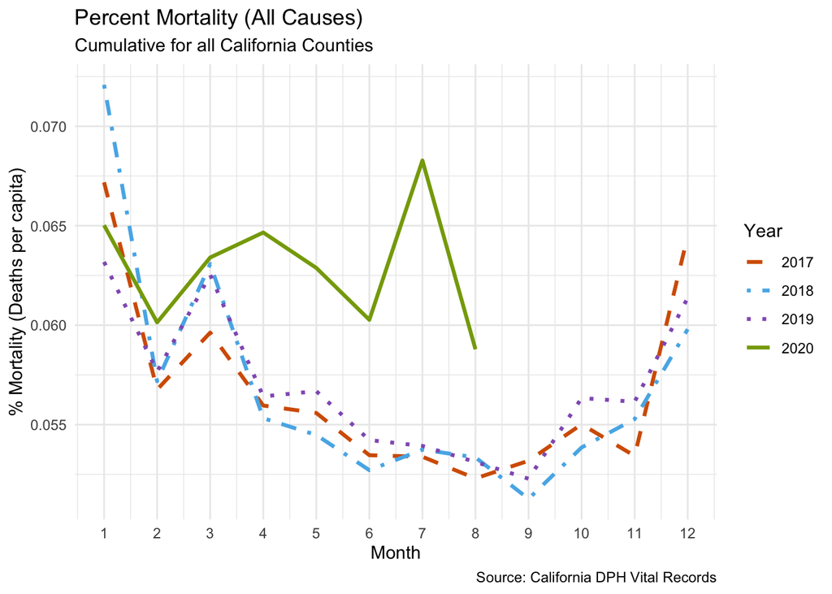

#### Question 14 [1 point]:

Why did this happen and how could you fix it? (**There is more than one correct answer possible.**) Could you have made your maps the way you did in Section 2.7 and had them be accurate if we’d had a full 12 months’ of data for each year?

> This happened because the 2020 data are incomplete. Looking at the line graph, we can see that 2020 only contains data through August, while the other years contain all 12 months. As a result, when we calculated annual percent mortality in Section 2.7, we were comparing a partial year of data against full years. This would make the 2020 mortality percentages appear artificially lower than they actually were. One way to fix this would be to only compare the first eight months of every year so that all years are based on the same time period. Another option would be to exclude 2020 from the annual comparison until a complete year of data is available. We could also recalculate the annual summaries once the missing months are added. Yes, we could have made the maps in Section 2.7 and had them be accurate if we had all 12 months of data for each year. The issue was not with the mapping approach itself, but with the fact that the 2020 mortality data were incomplete, which led to an unfair comparison across years.